# Working in RStudio - Introduction

Laurie Stevison

# Installation of R and Rstudio

First, install R:

[figure not shown]

# Rstudio environment for R and Applications

Next, install RStudio:

[figure not shown]

https://www.rstudio.com

# Launch RStudio:

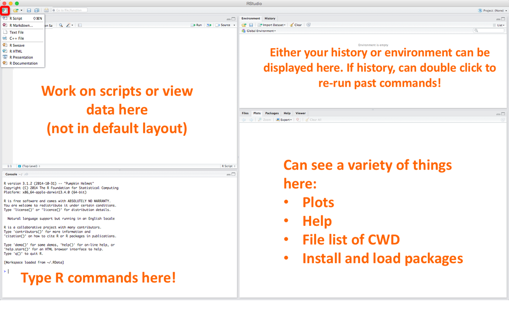

# Help in RStudio

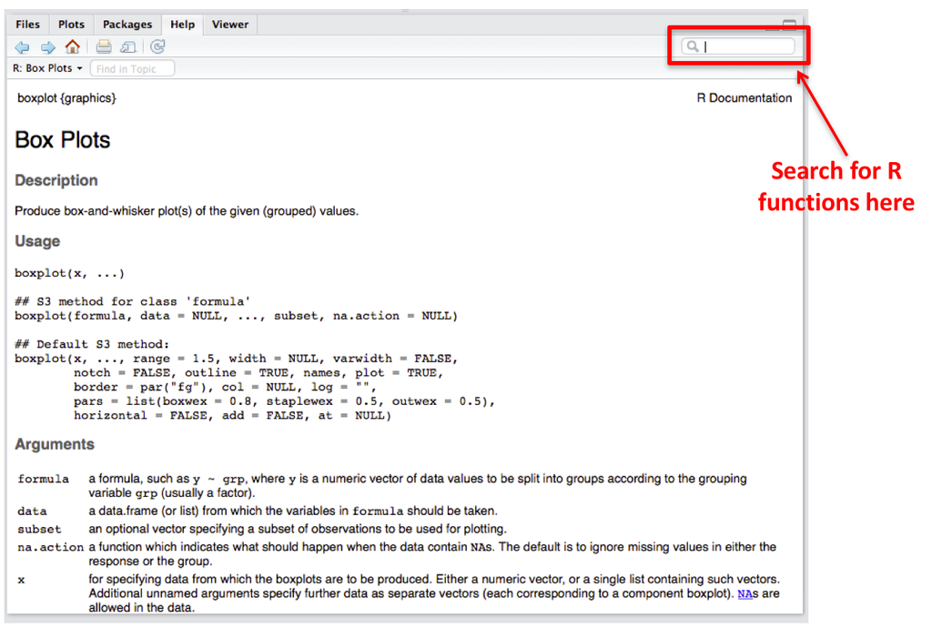

# Similarities between R and command line

- Most keyboard shortcuts are the same
- History saved in a hidden file “.Rdata”
- Can use tab to complete filenames and variables
- Can assign variables using multiple syntaxes:
  - a=seq(0,100,5)
  - a<-seq(0,100,5)
- Can do loops and if statements
- Kill runaway job using stop sign, like Cntrl + C

# Today’s Exercise: Calculating Coverage Along a Chromosome

- In genome analysis, the most often asked question by researchers is:
  - How many reads cover each site in the genome?
- Coverage (or depth) is calculated as read length (L) times the number of reads (N) divided by the genome size (G).
  - $C=\frac{N*L}{G}$

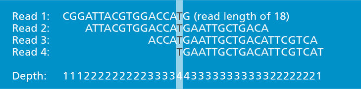

Image source: By Genomics Education Programme - Read, read length and read depth - read depth of ‘4’, CC BY 2.0, https://commons.wikimedia.org/w/index.php?curid=58405954

# Using samtools to get read depth output:

- A commonly used bioinformatics software for analyzing genome sequence alignment files (bam format) is [samtools](http://www.htslib.org/).
- Specifically, we have used `samtools depth` to output this information in long form.
- Because the output is so large, we will use R to read in the output and understand it.
- Today’s dataset was aligned to the *Drosophila pseudoobscura* reference genome.
  - Specifically, you have been provided reads aligned to the genome, with the first 50 kilobases of each contig on the 4th chromosome subsetted.
  - The raw sequences used to make this file are from a [published study](http://dx.doi.org/10.1098%2Frstb.2011.0250), which is archived in [NCBI’s short read archive](https://www.ncbi.nlm.nih.gov/sra/) (SRP007802).

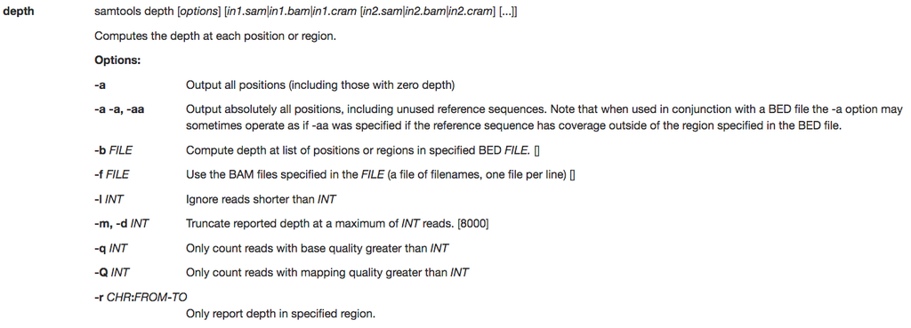

`samtools depth options`

# What you will be doing today:

- First, you will read the `samtools depth` output into R
- You will learn to manipulate data in R and make subsets
- You will calculate basic summary statistics of coverage
- You will examine the coverage information visually using a histogram
- Finally, you will plot coverage along a single chromosome

# Reproducibility and bioinformatics

- During today’s exercise, you will create a script to automate each step in your handout
- This script will enable you to re-do this analysis anytime in the future
- More importantly, you can change the input and use this script on any data file similar to the input provided
- Automating this process via a script means your results are directly comparable because the methods are identical
- Being able to get the same results every time is the definition of [reproducibility](https://en.wikipedia.org/wiki/Reproducibility) and is fundamental to the validity of bioinformatics research

# Let’s get started!

- Refer to the instructions on your handout.
- Work with others at your table.
- If you finish early, help others.
- If you are having trouble, ask for help.

# Handout Review

# Steps 1-3: Download and unzip input file provided.

- Make a folder for this exercise.
- Set the working directory to that folder.
- Open an RScript and save it as coverage.R.
- Save the script as you go so you can re-run this exercise anytime you want!

# Step 4a: read in data

```r
samtools.depth=read.table(file="chr4.depth.out")
#View(samtools.depth)
```

# Step 4b: test functions head, tail and length on your data frame.

```r
head(samtools.depth)
```

```
##            V1 V2 V3
## 1 chr4_group1  2  1
## 2 chr4_group1  3  2
## 3 chr4_group1  4  2
## 4 chr4_group1  5  2
## 5 chr4_group1  6  2
## 6 chr4_group1  7  2
```

```r
tail(samtools.depth)
```

```
##                 V1    V2 V3
## 249995 chr4_group5 57294  8
## 249996 chr4_group5 57295  7
## 249997 chr4_group5 57296  7
## 249998 chr4_group5 57297  7
## 249999 chr4_group5 57298  6
## 250000 chr4_group5 57299  6
```

```r
length(samtools.depth)
```

```
## [1] 3
```

Were you surprised by the output of length?

# Step 4c: redo length calculation on vector `V1`:

```r
length(samtools.depth$V1)
```

```
## [1] 250000
```

Each column in this file is a vector (default labeled `V1..V3`). By specifying a single vector within the data frame we get a length calculation that matches the environment tab information.

# Step 4d: make new variables/objects by extracting rows and columns in this dataset:

```r
col3=samtools.depth[,3]
row19=samtools.depth[19,]
cell3_19=samtools.depth[19,3]
```

# Step4e: repeat `head`, `tail`, and `length` on the new objects:

```r
head(col3)
```

```
## [1] 1 2 2 2 2 2
```

```r
tail(row19)
```

```
##             V1 V2 V3
## 19 chr4_group1 20  3
```

```r
length(col3)
```

```
## [1] 250000
```

# Step 4f: Subset a single contig, `chr4_group5`:

```r
chr4_group5=subset(samtools.depth,V1=="chr4_group5")
```

# Step 4g: Repeat on another contig:

```r
#figure out the name of another contig:
unique(samtools.depth$V1)
```

```
## [1] chr4_group1 chr4_group2 chr4_group3 chr4_group4 chr4_group5
## Levels: chr4_group1 chr4_group2 chr4_group3 chr4_group4 chr4_group5
```

```r
#we've already subsetted chr4_group5, so let's subset chr4_group2:
chr4_group2=subset(samtools.depth,V1=="chr4_group2")
```

# Step 5a & b: calculate mean and standard deviation for coverage:

```r
#mean
mean(samtools.depth$V3)
```

```
## [1] 10.80083
```

```r
#sd
sd(samtools.depth$V3)
```

```
## [1] 6.152665
```

```r
#5c: do this again on your subsetted contig:
mean(chr4_group5$V3)
```

```
## [1] 9.38386
```

```r
sd(chr4_group5$V3)
```

```
## [1] 4.758181
```

What are some reasons you would expect coverage to be different in one contig or one region of a chromosome as compared to the whole genome?

# Step 6a & b: make a histogram of both data frames:

A histogram shows the frequency of each coverage level throughout our dataset.

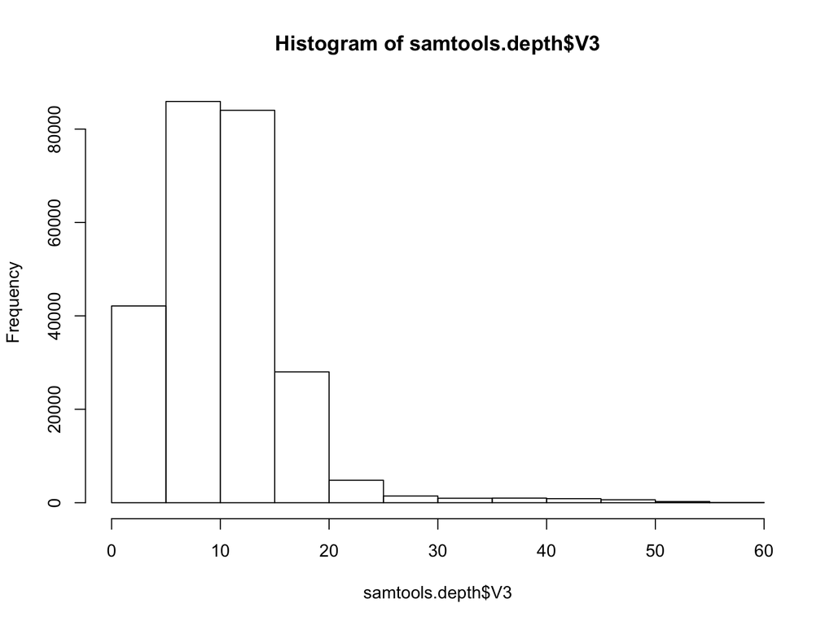

```r
#full dataset
hist(samtools.depth$V3)
```

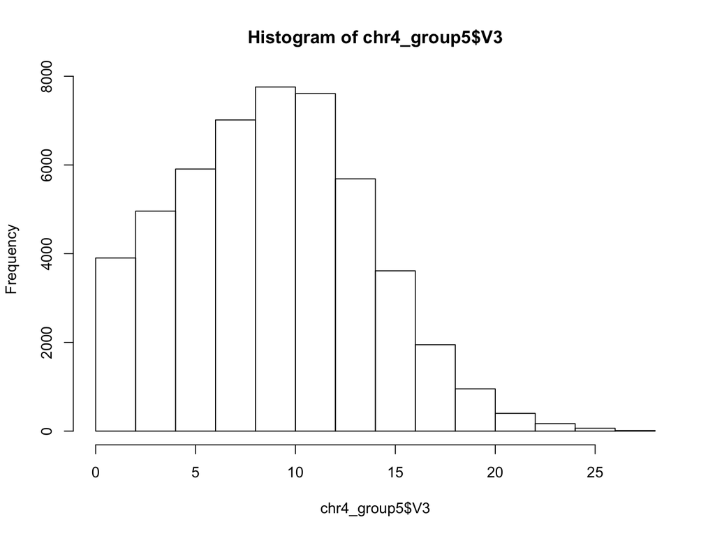

```r
#subsetted contig only
hist(chr4_group5$V3)
```

Again, what are some reasons you would expect the distribution of coverage to be different in one contig or one region of a contig as compared to the whole genome?

# Step 6c: plot coverage along the contig:

Read about the command plot in help and work to make your graph look nice by adding color, a title and names for the axes that are more informative than the defaults.

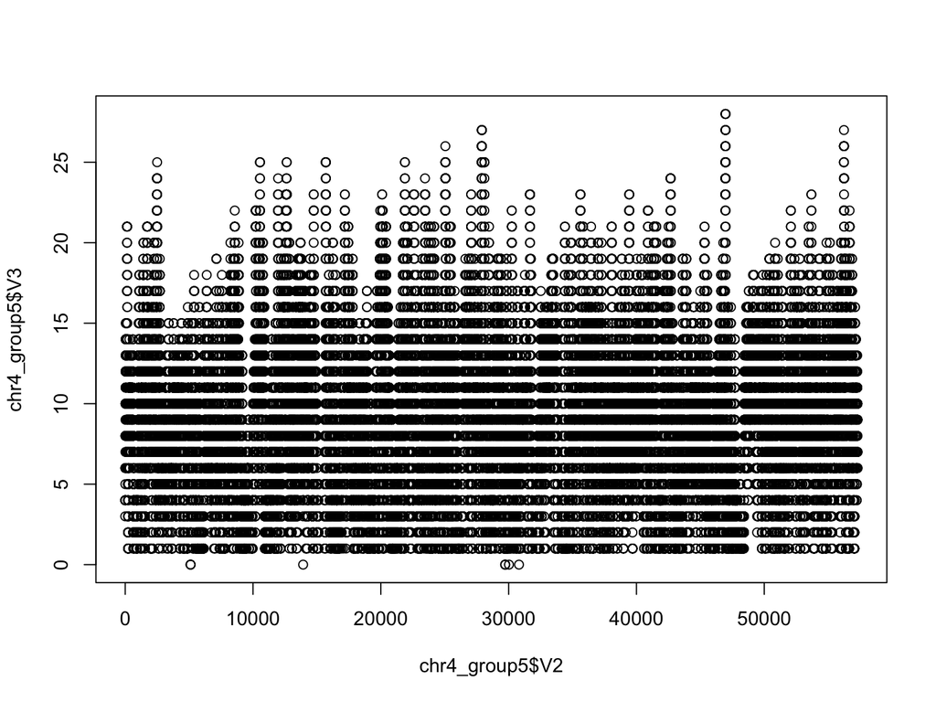

```r
#use function plot:
plot(chr4_group5$V2,chr4_group5$V3)
```

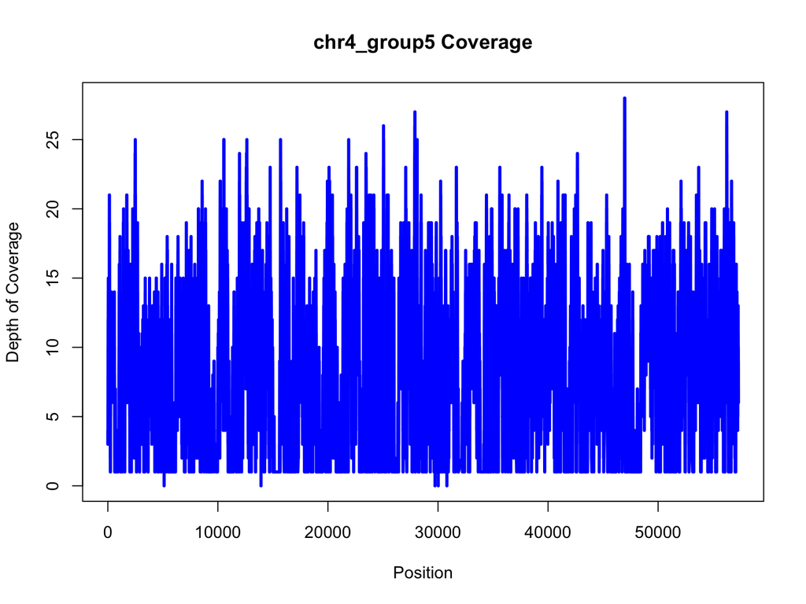

```r
#some steps to make it look nice:
plot(chr4_group5$V2,chr4_group5$V3,xlab="Position",ylab="Depth of Coverage",main="chr4_group5 Coverage",type="l",lwd=3,col="blue")
```

Note I’ve added a title, labeled each axis and colored the line. What changes did each of you make?

# Resources to continue learning R

- Getting started in R: Excellent tutorial
  - http://tryr.codeschool.com/
- Web-based resources:
  - http://www.statmethods.net/ (Comprehensive)
  - http://www.harding.edu/fmccown/r/ (Graphs)
- Books:
  - Getting started with R: An introduction for Biologists
  - R in Action: Data Analysis and Graphics in R
  - Primer to Analysis of Genomic Data using R
  - Graphical Data Analysis with R